# Week 2 - Part 1: Visualizing Association between Two Qauntitative Variables - Scatter Plot (Fundamentals of dataVis: Chapter 12)

## 3.4 Self Defined Colors

If you don’t like the default color, you can also specify it. `scale_color_manual()` can be used for lines and points.

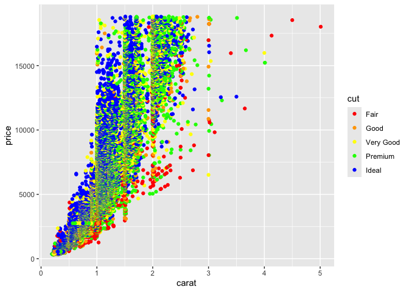

```r
ggplot() +
  geom_point(aes(x=carat,y=price,color=cut),data=diamonds)+
  scale_color_manual(values=c("red","orange","yellow","green","blue"))
```

## 3.5 Other Color Schemes

- RGB triplet - combinations of different amounts of red, green, and blue (e.g., `Red:255, Green:0, Blue:0` represents the color `Red`)
- Hexadecimal format (e.g., `Red:FF, Green:00, Blue:00` or `#FF0000`)
- #000000 : Black
- #FFFFFF : White
- Ref: http://www.fifi.org/doc/wwwcount/Count2.5/rgb.txt.html
- 1- viridis: printer-friendly, uniform and easy to read by those with colorblindness - `scale_color_viridis()` and `scale_fill_viridis()`
- 2- RColorBrewer: contains 3 types of color palettes: sequential, diverging, and qualitative - `scale_color_brewer()` and `scale_fill_brewer()`
- 3- Grey color pallet: `scale_color_grey()` and `scale_fill_grey()`
- Ref: https://www.datanovia.com/en/blog/top-r-color-palettes-to-know-for-great-data-visualization/

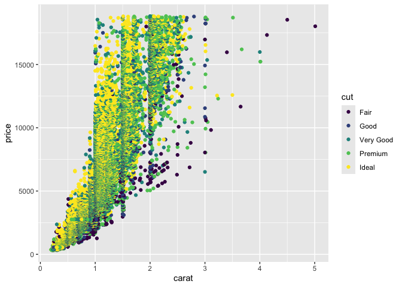

```r
ggplot() +
  geom_point(aes(x=carat,y=price,color=cut),data=diamonds)+
  scale_color_viridis_d() # d stands for discrete
```

```r
# scale_color_viridis_d() : discrete data
# scale_color_viridis_c() : continuous data
# scale_color_viridis_b() : bin continuous data

# viridis color palettes
# 1. printer-friendly
# 2. perceptually uniform; a change of the same amount in a color value should produce a change of about the same visual importance
# 3. colorblind-friendly
```

Refer for this for more details about the colors https://www.datanovia.com/en/blog/ggplot-colors-best-tricks-you-will-love/

## 3.6 Colorblind-friendly Color Schemes.

- About 1 in 12 men (8%) and 1 in 200 women in the world are color blind.
- https://www.nceas.ucsb.edu/sites/default/files/2022-06/Colorblind%20Safe%20Color%20Schemes.pdf
- https://r-graphics.org/recipe-colors-palette-discrete-colorblind
- R package `colorBlindness`: https://cran.r-project.org/web/packages/colorBlindness/vignettes/colorBlindness.html#Safe_colorsets
- http://www.cookbook-r.com/Graphs/Colors_(ggplot2)/#a-colorblind-friendly-palette

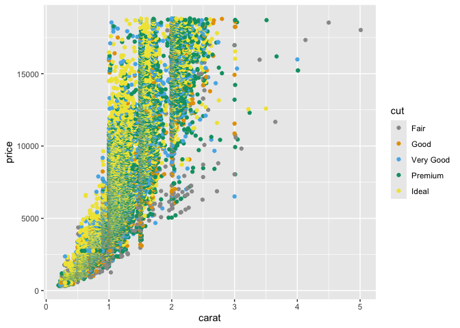

```r
ggplot() +
  geom_point(aes(x=carat,y=price,color=cut),data=diamonds) +
  scale_color_manual(values=c("#999999", "#E69F00", "#56B4E9", "#009E73","#F0E442"))
```

## 3.7 Problem: Overplotting

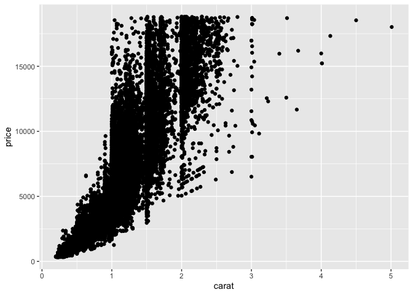

```r
ggplot() +
  geom_point(aes(x=carat,y=price),data=diamonds)
```

```r
# Any problems?
```

### 3.7.1 Solution: Use `geom_count()` or `geom_hex()`

Can summarize the number of points at each location and display that in some way, using `geom_count()` or `geom_hex()`

- `geom_count`: a variant `geom_point()` that counts the number of observations at each location, then maps the count to point area. It useful when you have discrete data and overplotting (https://ggplot2.tidyverse.org/reference/geom_count.html)
- `geom_hex()`: Divides the plane into regular hexagons, counts the number of cases in each hexagon, and then (by default) maps the number of cases to the hexagon fill (https://ggplot2.tidyverse.org/reference/geom_hex.html)

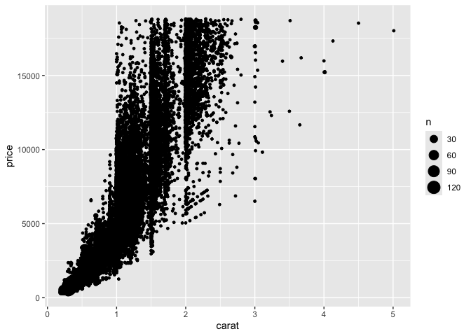

```r
ggplot() +
  geom_count(aes(x=carat,y=price),data=diamonds)
```

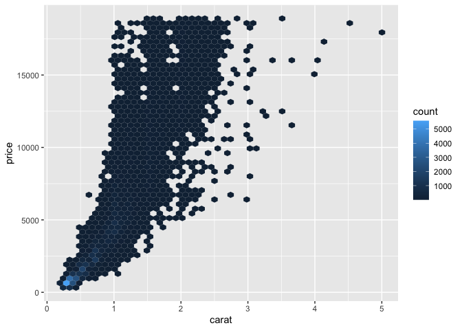

```r
ggplot() +
  # bins: numeric vector giving number of bins in both vertical and horizontal directions. Set to 30 by default.
  geom_hex(aes(x=carat,y=price),data=diamonds, bins=50)
```

### 3.7.2 Add alpha blending

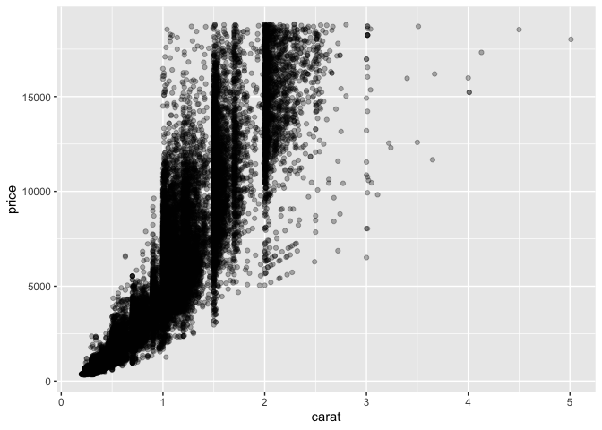

```r
# Reduce the alpha level to make each point semi-transparent
ggplot() +
  geom_point(aes(x=carat,y=price),data=diamonds,alpha=0.3)
```

## 3.8 Add Labels

Adding labels for the axes can also be regarded as a layer

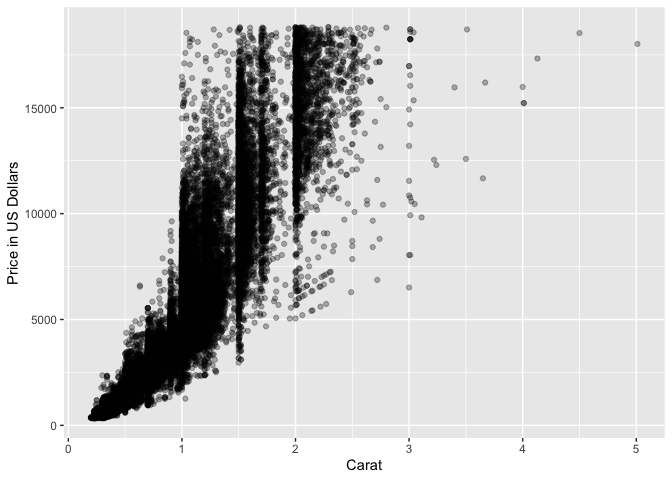

```r
ggplot() +
  geom_point(aes(x=carat,y=price),data=diamonds,alpha=0.3) +
  labs(x="Carat",y="Price in US Dollars") # title also can be added here
```

## 3.9 Add Titles

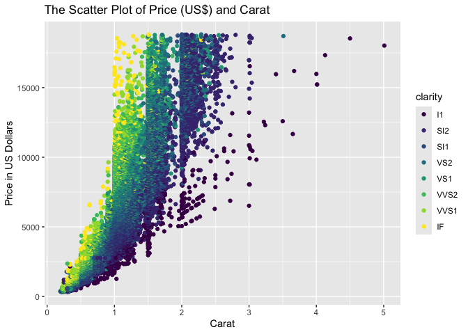

```r
ggplot() +
  geom_point(aes(x=carat, y=price,color=clarity),
             data=diamonds) +
  labs(x="Carat", y="Price in US Dollars") +
  # title using ggtitle() Or inside labs(title = ) : labs(x="Carat", y="Price in US Dollars", title = "The Scatter Plot of Price (US$) and Carat") +
  ggtitle("The Scatter Plot of Price (US$) and Carat")
```

## 3.10 Change size/shape of point

- Aesthetic specifications:
- http://www.sthda.com/english/wiki/ggplot2-point-shapes
- https://ggplot2.tidyverse.org/articles/ggplot2-specs.html

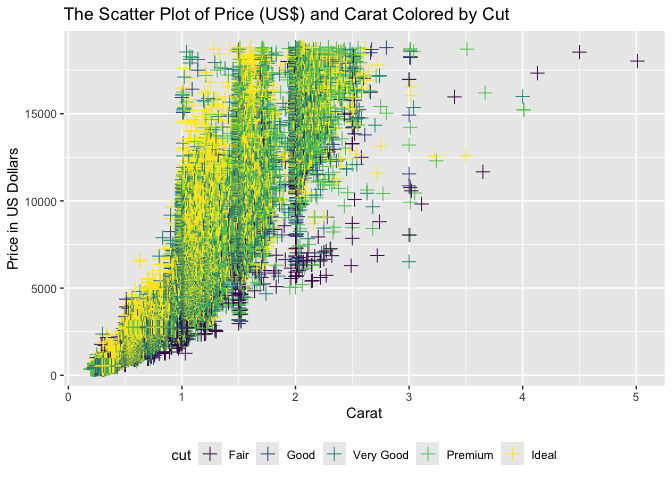

```r
ggplot() +
  geom_point(aes(x=carat, y=price,color=cut),
             size=3,shape=3,data=diamonds) +
  labs(x="Carat", y="Price in US Dollars")+
  ggtitle("The Scatter Plot of Price (US$) and Carat Colored by Cut")+
  theme(legend.position = "bottom") #top, left, right
```

```r
#size - (default: 0.5) diameter of the point
#shape - (default: 16=dot) the shape of the point
```

## 3.11 Legends

Let’s change name of the legend

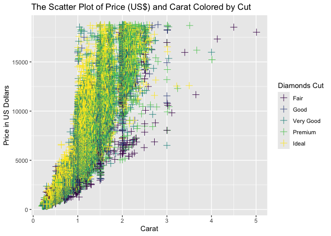

```r
ggplot() +
  geom_point(aes(x=carat, y=price,color=cut),
             size=3,shape=3,data=diamonds) +
  # For changing legend title we also can use guides() and guide_legend() functions: guides(colour=guide_legend(title = "Diamonds Cut"))
  # We will explore the details of the guieds() function later
  labs(x="Carat", y="Price in US Dollars",color="Diamonds Cut")+
  ggtitle("The Scatter Plot of Price (US$) and Carat Colored by Cut")+
  theme(legend.position = "right")
```

## 3.12 Display Layout panels in a grid

- https://ggplot2.tidyverse.org/reference/facet_grid.html
- Syntax: facet_grid(var_vertical ~ var_horizontal)
- Create a matrix of panels defined by row and column faceting variables. It is most useful when you have two discrete variables, and all combinations of the variables exist in the data. If you have only one variable with many levels, try `facet_wrap()`

### 3.12.1 Vertical direction

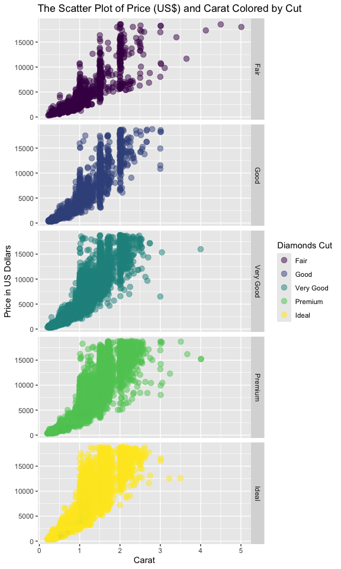

```r
ggplot() +
  geom_point(aes(x=carat, y=price,color=cut),
             size=3,alpha=0.5,data=diamonds) +
  labs(x="Carat", y="Price in US Dollars",color="Diamonds Cut")+
  ggtitle("The Scatter Plot of Price (US$) and Carat Colored by Cut")+
  theme(legend.position = "right")+
  facet_grid(cut~.)
```

### 3.12.2 Horizontal direction

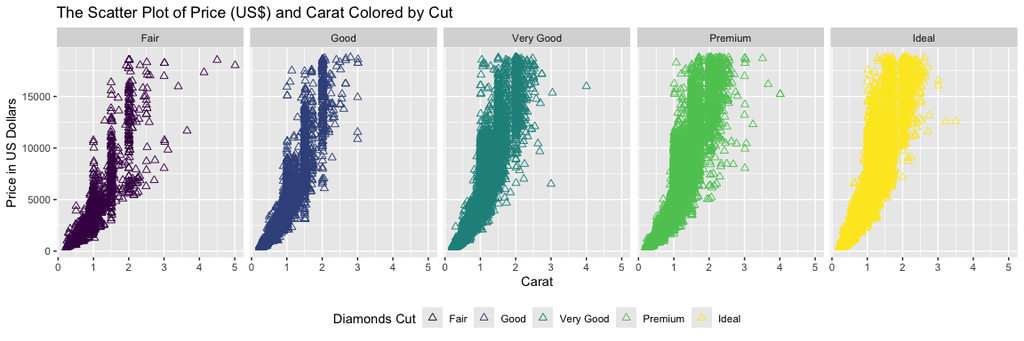

```r
p1 <- ggplot() +
  geom_point(aes(x=carat, y=price,color=cut),
             size=2,shape=2,data=diamonds) +
  labs(x="Carat", y="Price in US Dollars",color="Diamonds Cut")+
  ggtitle("The Scatter Plot of Price (US$) and Carat Colored by Cut")+
  theme(legend.position = "bottom")

p1+facet_grid(.~cut)
```

## 3.13 Complete themes

- https://ggplot2.tidyverse.org/reference/ggtheme.html

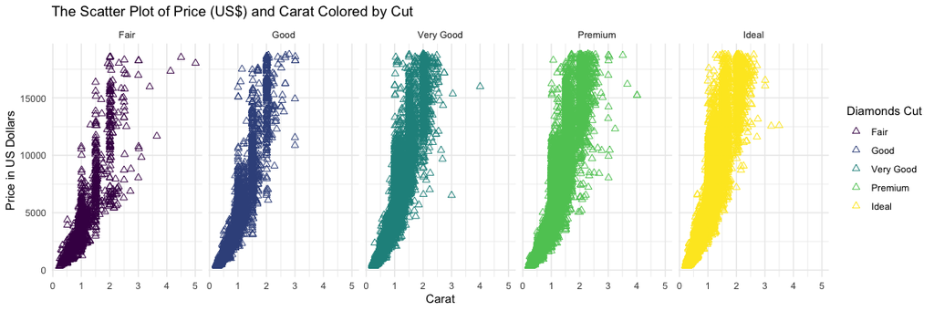

```r
p1 +
  facet_grid(.~cut) +
  theme_minimal()
```

```r
  #theme_classic() - theme_gray() - theme_bw() - theme_light() - theme_void ()
```